# Election

4dollar

2019년 12월 13일

# 1 개요

## 1.1 주제선정이유

```r
library(tidyverse)
library(leaflet)
mymap = leaflet() %>% addTiles()

election  = geojsonio::geojson_read("election.json", what = "sp")

# 지도에 색을 입히기 위해서 파레트 생성
pal = colorFactor(c("#0D7440", "#2A88C5",  "#C10D0D"), c("국민의당", "더불어민주당","새누리당"))

# 툴팁에 담을 정보 생성
labs = lapply(seq(nrow(election@data)), function(i) {
  paste0( '<p><b>', election@data[i, "선거구"]," : ",election@data[i, "읍면동명"], '</b></p><p>',
          "<b>당선 : ", election@data[i, "당선"], '</b><p></p>',
          "국민의당 : ", election@data[i, "국민의당"],'</p><p>',
          "더불어민주당 : ", election@data[i, "더불어민주당"], '</p><p>',
          "새누리당 : ", election@data[i, "새누리당"], '</p>')
})

# 선거구 경계 생성
election_gu = maptools::unionSpatialPolygons(election, election$선거구)

poly2 = leaflet(election) %>%
  addTiles %>%
  addPolygons(
    # 폴리곤 내부
    fillColor = ~pal(당선), fillOpacity = 0.5,
    # 폴리곤 경계
    weight = 1, opacity = 1, color = "white", dashArray=3,
    # 라벨
    label=lapply(labs, htmltools::HTML),
    # 하이라이트
    highlightOptions = highlightOptions(
      color = "#00ff00", opacity = 1, weight = 2, fillOpacity = 1,
      bringToFront = T, sendToBack = T))%>%
  addLegend(pal = pal, values = ~당선, opacity = 0.7, title = NULL, position = "bottomright") %>%
  addPolylines(
    data=election_gu,
    weight = 1.5,
    opacity = 1,
    color = "black")

crosstalk::bscols(poly2)
```

[interactive chart not shown]

단순히 생각해도, 투표에 영향을 주는 요소는 무수히 많습니다.

그렇다면 ‘과연 어떠한 요소가 실질적으로 투표에 영향을 줄까?’

이러한 의문으로 시작하여 저희 조는 투표에 영향을 줄 만한 변수들을 생각해봤고, 그 변수들을 이용하여 다음 총선을 예측해보기로 하였습니다.

## 1.2 데이터 수집과정

정량적인 데이터를 사용해야 하기 때문에, 선거에 통용되는 통설들은 배제하고 수치화 할 수 있는 데이터들을 수집했습니다.

```r
library(tidyverse)
library(readr)
library(reticulate)
```

```r
data<-read_csv(file="https://raw.githubusercontent.com/lhmlhm1111/Data_GongHak/master/2008_oldage.csv")

data %>%
  DT::datatable() %>%
  DT::formatRound(2:6, digits=0)
```

|  | 기간 | 컬럼1 | 컬럼2 | 계 | 남자 | 여자 | 계_1 | 남자_1 | 여자_1 |
| --- | --- | --- | --- | --- | --- | --- | --- | --- | --- |
| 1 | 2008 | 합계 | 합계 | 10456034 | 5184732 | 5271302 | 890052 | 379518 | 510534 |
| 2 | 2008 | 종로구 | 소계 | 179754 | 89725 | 90029 | 19921 | 8669 | 11252 |
| 3 | 2008 | 종로구 | 사직동 | 10451 | 4941 | 5510 | 1354 | 589 | 765 |
| 4 | 2008 | 종로구 | 삼청동 | 3801 | 1850 | 1951 | 581 | 239 | 342 |
| 5 | 2008 | 종로구 | 부암동 | 11933 | 5904 | 6029 | 1429 | 646 | 783 |
| 6 | 2008 | 종로구 | 평창동 | 19757 | 9620 | 10137 | 2276 | 973 | 1303 |
| 7 | 2008 | 종로구 | 무악동 | 8693 | 4224 | 4469 | 883 | 376 | 507 |
| 8 | 2008 | 종로구 | 교남동 | 9407 | 4595 | 4812 | 1095 | 485 | 610 |
| 9 | 2008 | 종로구 | 가회동 | 6044 | 2910 | 3134 | 794 | 331 | 463 |
| 10 | 2008 | 종로구 | 종로1.2.3.4가동 | 8645 | 4852 | 3793 | 1205 | 589 | 616 |

[output cut: 454 more lines]

*데이터수집예시*

비슷한 과정으로 수치화 할 수 있는 데이터를 최대한 수집했습니다.

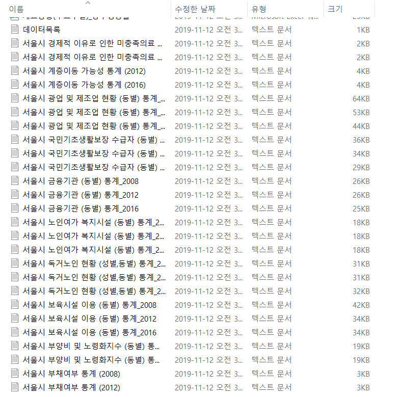

데이터수집목록

데이터 수집은 [서울시열린데이터광장](https://data.seoul.go.kr)을 참고하였습니다.

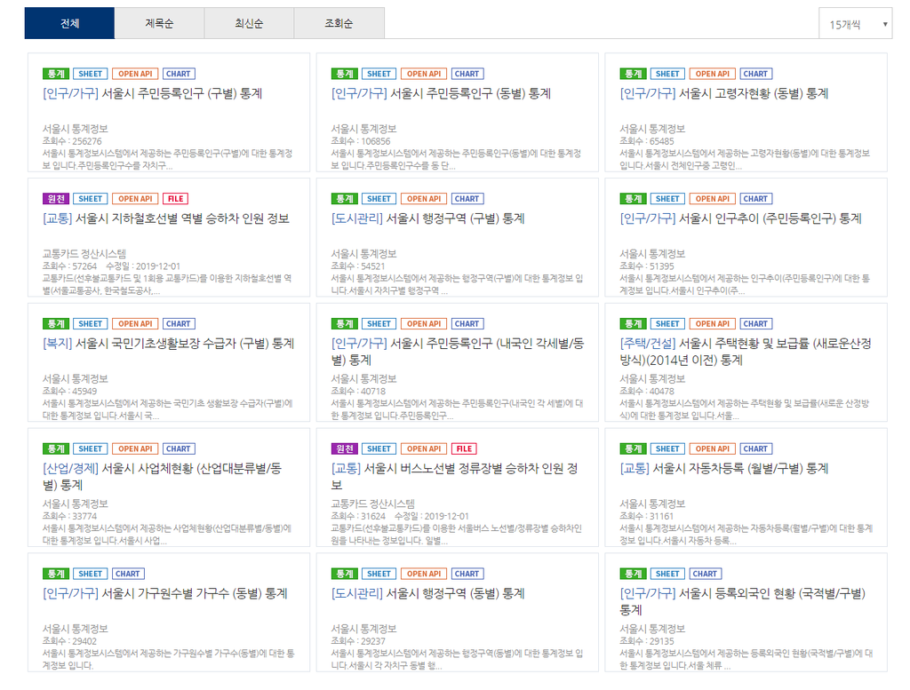

# 2 전처리과정

앞서 모은 데이터들을 활용하기 위해서 전처리 하는 과정을 거쳤습니다.

```python
import pandas as pd
import numpy as np
import os
import re

gangnamgap = pd.read_excel("https://github.com/lhmlhm1111/Data_GongHak/raw/master/data/seoul/%EA%B0%9C%ED%91%9C%EC%83%81%ED%99%A9(%ED%88%AC%ED%91%9C%EA%B5%AC%EB%B3%84)_%EA%B0%95%EB%82%A8%EA%B5%AC%EA%B0%91.xlsx")
header = gangnamgap.iloc[2,:4]

a = pd.Series(gangnamgap.iloc[3,4:].values)

a = a.apply(lambda x: str(x).split("\n")[0])

a = a[(a!="")&(a!="nan")]

gangnamgap = gangnamgap[gangnamgap['Unnamed: 1']=="소계"]
gangnamgap = gangnamgap.iloc[:,:len(a)+3]
gangnamgap.columns = np.append(header,a[:-1])
gangnamgap.head()
```

```
##     읍면동명 투표구명   선거인수    투표수  새누리당 더불어민주당
## 9    신사동   소계  14827   7771  4774   2817
## 16  논현1동   소계  21876   8939  3966   4769
## 23  논현2동   소계  19063   8887  4639   4017
## 30  압구정동   소계  22435  12118  8301   3539
## 39   청담동   소계  24507  12470  7366   4777
```

```python
os.chdir("C:/Users/JW/Desktop/presentation/data")
filelist = os.listdir("seoul")[1:]
first = gangnamgap
gangnamgap['자치구'] = "강남구"
for file in filelist:
    data=pd.read_excel(f'seoul/{file}')
    a=pd.Series(data.iloc[3,4:].values)
    a = a.apply(lambda x: str(x).split("\n")[0])
    a = a[(a!="")&(a!="nan")]
    data = data[data['Unnamed: 1']=="소계"]
    data = data.iloc[:,:len(a)+3]
    data.columns = np.append(header,a[:-1])
    gu = re.findall("_\w+구", file)[0][1:]
    data['자치구'] = gu
    first = first.append(data, sort=False)

Second = first[["읍면동명","자치구", "선거인수", "새누리당", "더불어민주당", "국민의당"]]
Second.읍면동명=Second.읍면동명.apply(lambda x: re.sub(r'제', '', str(x)))
Second.읍면동명=Second.읍면동명.apply(lambda x: re.sub(r'·', '.', str(x)))

old_man = pd.read_csv("https://github.com/lhmlhm1111/Data_GongHak/raw/master/data/%EB%8F%85%EB%A6%BD%EB%B3%80%EC%88%98_%EB%8D%B0%EC%9D%B4%ED%84%B0_%ED%98%B8%EC%8B%9D/%EC%84%9C%EC%9A%B8%EC%8B%9C%20%EB%8F%85%EA%B1%B0%EB%85%B8%EC%9D%B8%20%ED%98%84%ED%99%A9%20(%EC%84%B1%EB%B3%84%2C%EB%8F%99%EB%B3%84)%20%ED%86%B5%EA%B3%84_2016.txt", engine="python" ,encoding="utf-8", sep="\t")

old_man = old_man[["동", "자치구", "합계"]]
old_man=old_man.rename(columns={"동": "읍면동명"})
old_man = old_man.drop([0,1,2])

old_man.자치구=old_man.자치구.apply(lambda x: re.sub(r'성동', '중', str(x)))
old_man[old_man.자치구=="중구"]
```

```
##        읍면동명 자치구     합계
## 20       소계  중구  5,528
## 21      소공동  중구     54
## 22      회현동  중구    461
## 23       명동  중구    157
## 24       필동  중구    228
## 25      장충동  중구    187
## 26      광희동  중구    352
## 27     을지로동  중구    224
## 28     신당5동  중구    411
## 29      황학동  중구    514
## 30      중림동  중구    440
## 31      신당동  중구    385
## 32      다산동  중구    503
## 33      약수동  중구    755
```

[output cut: 20 more lines]

```python
second_old_man = pd.merge(Second, old_man, how='left')
second_old_man = second_old_man.rename(columns={"합계":"독거노인수"})

buyang = pd.read_csv("https://github.com/lhmlhm1111/Data_GongHak/raw/master/data/%EB%8F%85%EB%A6%BD%EB%B3%80%EC%88%98_%EB%8D%B0%EC%9D%B4%ED%84%B0_%ED%98%B8%EC%8B%9D/%EC%84%9C%EC%9A%B8%EC%8B%9C%20%EB%B6%80%EC%96%91%EB%B9%84%20%EB%B0%8F%20%EB%85%B8%EB%A0%B9%ED%99%94%EC%A7%80%EC%88%98%20(%EB%8F%99%EB%B3%84)%20%ED%86%B5%EA%B3%84_2016.txt", engine="python" ,encoding="utf-8", sep="\t")

buyang = buyang.rename(columns={"동":"읍면동명"})
buyang = buyang[~buyang.읍면동명.isin(["소계", "합계"])]
buyang=buyang.drop("기간", axis=1)

buyang.자치구=buyang.자치구.apply(lambda x: re.sub(r'성동', '중', str(x)))

old_man_buyang=pd.merge(second_old_man, buyang, how='left')
old_man_buyang.head()
```

```
##    읍면동명  자치구   선거인수  새누리당 더불어민주당 국민의당 독거노인수  유년부양비  노년부양비  노령화지수
## 0   신사동  강남구  14827  4774   2817  NaN   380   15.8   19.1  121.3
## 1  논현1동  강남구  21876  3966   4769  NaN   500    7.2   12.4  172.1
## 2  논현2동  강남구  19063  4639   4017  NaN   409   11.9   14.9  124.8
## 3  압구정동  강남구  22435  8301   3539  NaN   647   20.0   21.4  107.1
## 4   청담동  강남구  24507  7366   4777  NaN   491   16.3   15.2   93.5
```

비슷한 방식으로 다른 독립변수들도 모두 전처리를 해주었습니다.

여기까진 데이터를 단순히 전처리하는 과정이었습니다.

그 결과 결측치를 처리할 수 없었기 때문에, 아래와 같이 결측치를 처리해주었습니다.

```python
import pandas as pd
election_2016=pd.read_csv("https://raw.githubusercontent.com/lhmlhm1111/Data_GongHak/master/%EC%A0%84%EC%B2%98%EB%A6%AC_1101(%EC%88%98%EC%A0%95).csv")
election_2016["독거노인수"]=election_2016["독거노인수"].apply(lambda x : int(str(x).replace(",", "")))
election_2016["기초수급자인원수"]=election_2016["기초수급자인원수"].apply(lambda x : int(str(x).replace(",", "")))
election_2016["사업체수"]=election_2016["사업체수"].apply(lambda x : int(str(x).replace(",", "")))
election_2016["종사자수"]=election_2016["종사자수"].apply(lambda x : int(str(x).replace(",", "")))
election_2016["금융기관"]=election_2016["금융기관"].fillna(election_2016['금융기관'].median())
election_2016["보육시설"]=election_2016["보육시설"].apply(lambda x : str(x))
election_2016["보육시설"]=election_2016["보육시설"].replace("nan", 0)
election_2016["보육시설"]=election_2016["보육시설"].apply(lambda x : int(str(x).replace(",", "")))
election_2016["보육시설"]=election_2016["보육시설"].replace(0, election_2016['보육시설'].median())
election_2016["사업체 평균연령"]=election_2016["사업체 평균연령"].fillna(election_2016['사업체 평균연령'].median())
election_2016["장애등급"]=election_2016["장애등급"].fillna(election_2016['장애등급'].median())
election_2016["국민의당"]=election_2016["국민의당"].fillna(0)
election_2016=election_2016.drop("Unnamed: 0", axis=1)
election_2016["새누리당"]=election_2016["새누리당"].fillna(0)
election_2016
```

```
##         읍면동명  자치구   선거인수     새누리당   ...      보육시설  금융기관  사업체 평균연령    장애등급
## 0        신사동  강남구  14827   4774.0   ...     303.0  13.0     6.833   383.0
## 1       논현1동  강남구  21876   3966.0   ...     375.0  18.0     7.250   648.0
## 2       논현2동  강남구  19063   4639.0   ...     287.0  23.0     7.583   509.0
## 3       압구정동  강남구  22435   8301.0   ...     301.0  32.0     7.167   471.0
## 4        청담동  강남구  24507   7366.0   ...     507.0  21.0     7.583   584.0
## 5       역삼1동  강남구  31222   5285.0   ...     767.0  54.0     6.917   760.0
## 6       역삼2동  강남구  26632   6988.0   ...     528.0  15.0     7.833   672.0
## 7       삼성1동  강남구  11991   3792.0   ...     565.0  29.0     7.667   281.0
## 8       삼성2동  강남구  23856   6262.0   ...     733.0  17.0     8.000   567.0
## 9       대치1동  강남구  16660   6362.0   ...     294.0  15.0     7.750   266.0
## 10      대치2동  강남구  31132  10404.0   ...     504.0  21.0     9.000   707.0
## 11      대치4동  강남구  16885   3467.0   ...     617.0  15.0     6.500   368.0
## 12      도곡1동  강남구  17461   5405.0   ...     412.0  11.0     8.083   431.0
## 13      도곡2동  강남구  26147   9715.0   ...     343.0  22.0     8.500   499.0
```

[output cut: 49 more lines]

최종적으로 전처리 한 데이터의 모습입니다.

```r
data<-read_csv(file="https://raw.githubusercontent.com/lhmlhm1111/Data_GongHak/master/data/11-22totaldata.csv")

data %>%
  DT::datatable() %>%
  DT::formatRound(2:6, digits=0)
```

|  | year | 읍면동명 | 자치구 | 선거인수 | 새누리당 | 더불어민주당 | 국민의당 | 독거노인수 | 유년부양비 | 노년부양비 | 노령화지수 | 사업체수 | 종사자수 | 사업체 창업률 | 기초수급자인원수 | 보육시설 | 금융기관 | 사업체 평균연령 | 장애등급별 장애인현황 | 인구 | 면적 | 인구밀도 | 소득(동별) |
| --- | --- | --- | --- | --- | --- | --- | --- | --- | --- | --- | --- | --- | --- | --- | --- | --- | --- | --- | --- | --- | --- | --- | --- |
| 1 | 2016 | 신사동 | 강남구 | 14827 | 4774 | 2817 | 0 | 380 | 15.8 | 19.1 | 121.3 | 4503 | 27741 | 15.94 | 128 | 303 | 13 | 6.833 | 383 | 18349 | 1.89 | 9708 | 1925266.73 |
| 2 | 2016 | 신사동 | 관악구 | 20014 | 3752 | 3727 | 2796 | 701 | 10 | 13.9 | 138.1 | 1422 | 4712 | 11.67 | 661 | 538 | 2 | 8.999 | 924 | 26627 | 0.64 | 41605 | 269594.908 |
| 3 | 2016 | 논현1동 | 강남구 | 21876 | 3966 | 4769 | 0 | 500 | 7.2 | 12.4 | 172.1 | 5788 | 44157 | 17.78 | 356 | 375 | 18 | 7.25 | 648 | 24867 | 1.25 | 19894 | 2601180.323 |
| 4 | 2016 | 논현2동 | 강남구 | 19063 | 4639 | 4017 | 0 | 409 | 11.9 | 14.9 | 124.8 | 5656 | 60642 | 17.57 | 319 | 287 | 23 | 7.583 | 509 | 22639 | 1.47 | 15401 | 2403661.045 |
| 5 | 2016 | 압구정동 | 강남구 | 22435 | 8301 | 3539 | 0 | 647 | 20 | 21.4 | 107.1 | 4314 | 29474 | 16.16 | 48 | 301 | 32 | 7.167 | 471 | 28360 | 2.53 | 11209 | 3033472.24 |
| 6 | 2016 | 청담동 | 강남구 | 24507 | 7366 | 4777 | 0 | 491 | 16.3 | 15.2 | 93.5 | 4497 | 39652 | 14.21 | 210 | 507 | 21 | 7.583 | 584 | 30623 | 2.33 | 13143 | 3291842.314 |
| 7 | 2016 | 역삼1동 | 강남구 | 31222 | 5285 | 6839 | 0 | 679 | 6.5 | 10.1 | 154.3 | 15079 | 147157 | 19.18 | 415 | 767 | 54 | 6.917 | 760 | 36305 | 2.35 | 15449 | 4072414.906 |
| 8 | 2016 | 역삼2동 | 강남구 | 26632 | 6988 | 6513 | 0 | 453 | 21.4 | 11.3 | 53.1 | 3416 | 38937 | 16.77 | 343 | 528 | 15 | 7.833 | 672 | 37047 | 1.15 | 32215 | 4065204.579 |
| 9 | 2016 | 삼성1동 | 강남구 | 11991 | 3792 | 2228 | 0 | 243 | 14.6 | 15.4 | 105.5 | 4330 | 66958 | 16.77 | 107 | 565 | 29 | 7.667 | 281 | 15357 | 1.94 | 7916 | 1630845.018 |
| 10 | 2016 | 삼성2동 | 강남구 | 23856 | 6262 | 5159 | 0 | 479 | 19 | 12 | 63.3 | 3734 | 38887 | 17.89 | 324 | 733 | 17 | 8 | 567 | 30999 | 1.24 | 24999 | 3316969.214 |

[output cut: 837 more lines]